# esm204_hw4_version4

Andrew Salvador

5/24/2020

THE BEST VERSION!!

Attach necessary packages

```r
library(janitor)
library(tidyverse)
library(broom)
```

Build the functions, set variables t & T, everything else is given temp = temperature at year t K_t = fraction of economic activity retained at year t, if temperature is T(t) C_t = economic activity (“consumption”) at time t U_c = society’s utility from consumption discount rate r = delta + ng

```r
t = 100
T = 4.4
B = 0.05
g = 0.01
n = 0.50
delta = 0.005
r = delta + n*g
#temp = tauf

#FUNCTION 1 (temperature at year 't', temperature 'T' at year 100)
tauf = function(t,T)
{
  out = min(t*T/100, T)
  return(out)
}


#FUNCTION 2 (fraction of economic activity)
Keep = function(temp)
{
  out = exp(-B*temp^2)
  return(out)
}


#FUNCTION 3 (economic activity "consumption", grows at rate g, reduced by K)
Consumption = function(t,temp)
{
  out = Keep(temp)*exp(g*t)
  return(out)
}


#FUNCTION 4 (society's utility from consumption)
Utility = function(C)
{
  out = ((C)^(1-n))/(1-n)
  return(out)
}
```

QUESTION 1: PLOTS (a) Plot temperature over time for no climate change (T = 0), modest climate change (T = 2), and with extreme climate change (T = 8).

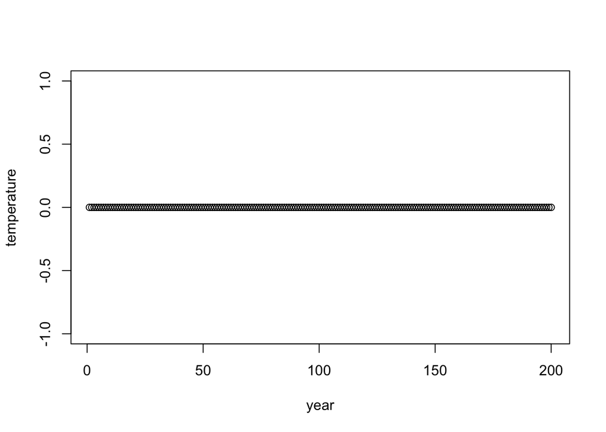

```r
# This generates a dataframe with temperature values from 0 to 200. Good for question 1(a)
# Temperature without climate change (T = 0) (wocc = without climate change)
tauf = function(t,T)
{
  out = min(t*T/100, T)
  return(out)
}

T = 0
DF_T_wocc = data.frame(year = seq(1,200), temperature = numeric(200))

for (t in seq(1,200))
{
  v = tauf(t,T)
  DF_T_wocc$temperature[t] = v
}

plot(DF_T_wocc)
```

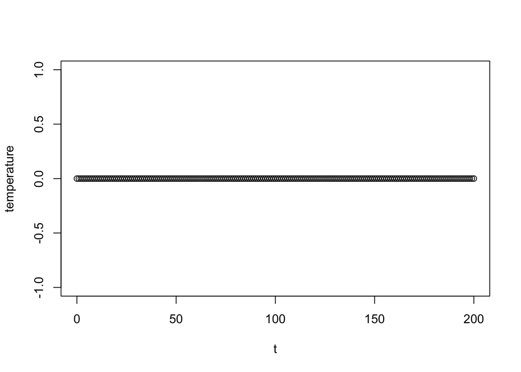

```r
# Trying a different dataframe for plotting temperature without climate change
t = 200
T = 0
B = 0.05
g = 0.01
n = 0.50
delta = 0.005

DF_T_wocc2 = data.frame(t=seq(0,200)) %>%
  rowwise() %>%
  mutate(temperature = tauf(t,T)) %>%
  mutate(K = Keep(temperature)) %>%
  mutate(C = Consumption(t,temperature)) %>%
  mutate(U = Utility(C)) %>%
  mutate(PVU = U/(1+r)^t)

DF_T_wocc2_plot <- DF_T_wocc2 %>%
  select(t, temperature)

plot(DF_T_wocc2_plot)
```

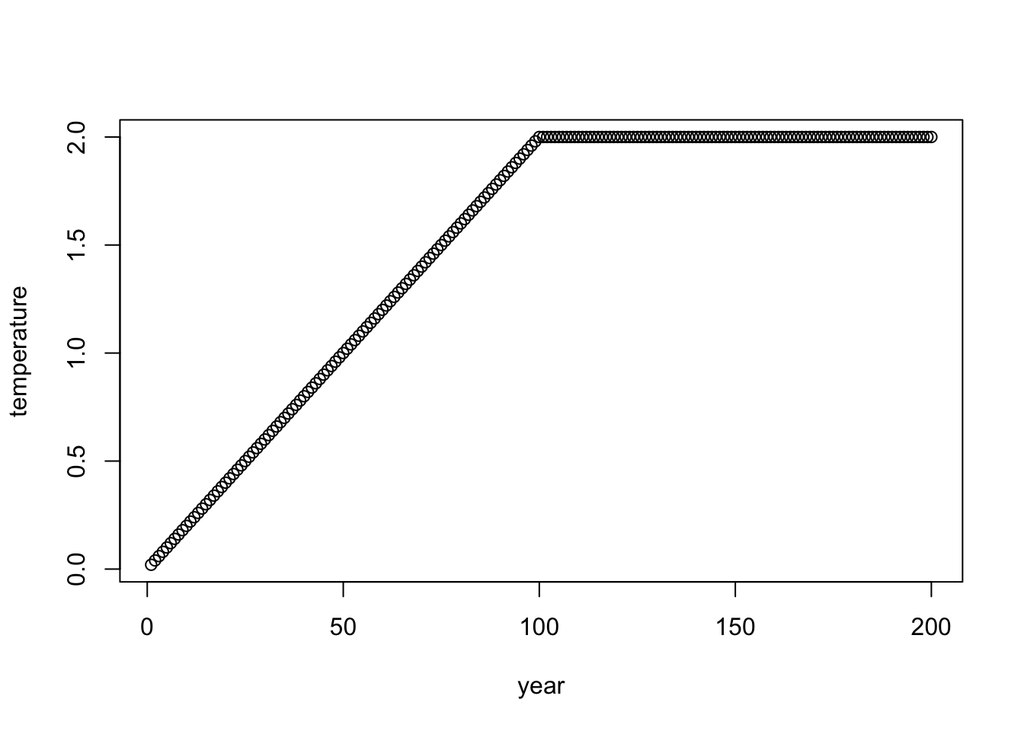

```r
# Temperature with modest climate change (T = 2) (mcc = modest climate change)
T = 2
DF_T_mcc = data.frame(year = seq(1,200), temperature = numeric(200))

for (t in seq(1,200))
{
  v = tauf(t,T)
  DF_T_mcc$temperature[t] = v
}

plot(DF_T_mcc)
```

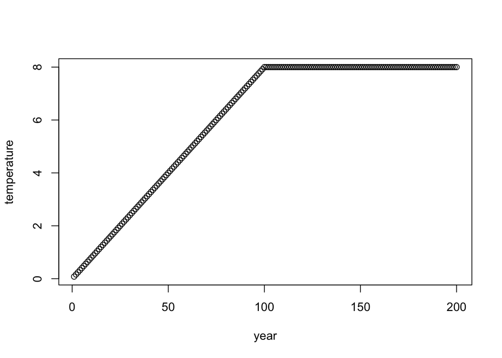

```r
# Temperature with extreme climate change (T = 8) (ecc = extreme climate change)
T = 8
DF_T_ecc = data.frame(year = seq(1,200), temperature = numeric(200))

for (t in seq(1,200))
{
  v = tauf(t,T)
  DF_T_ecc$temperature[t] = v
}

plot(DF_T_ecc)
```

2. Plot consumption over time for no climate change, modest climate change, and extreme climate change.

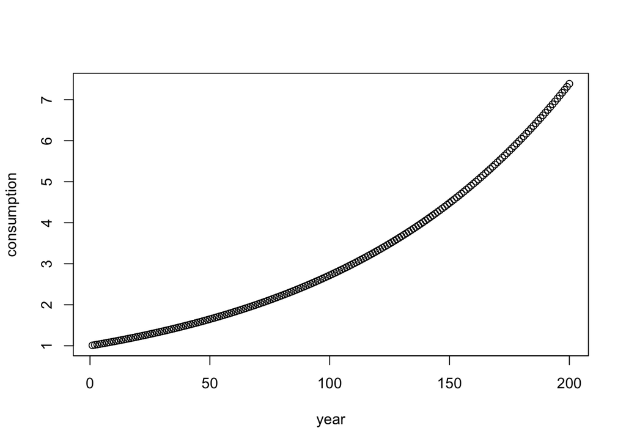

```r
# Consumption without climate change (C_wocc = consumption without climate change)
T = 0
temp = tauf(t,T)

Consumption = function(t,temp)
{
  out = Keep(temp)*exp(g*t)
  return(out)
}


DF_C_wocc = data.frame(year = seq(1,200), consumption = numeric(200))

for (t in seq(1,200))
{
  v = Consumption(t,temp)
  DF_C_wocc$consumption[t] = v
}

plot(DF_C_wocc)
```

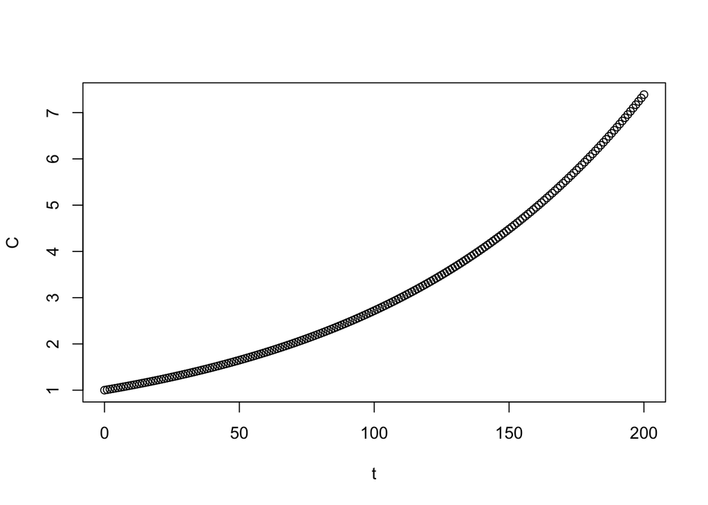

```r
# Method 2 to plot consumption without climate change (I think this one is correct)
t = 200
T = 0
B = 0.05
g = 0.01
n = 0.50
delta = 0.005

DF_C_wocc2 = data.frame(t=seq(0,200)) %>%
  rowwise() %>%
  mutate(temperature = tauf(t,T)) %>%
  mutate(K = Keep(temperature)) %>%
  mutate(C = Consumption(t,temperature)) %>%
  mutate(U = Utility(C)) %>%
  mutate(PVU = U/(1+r)^t) %>%
  select(t,C)

plot(DF_C_wocc2)
```

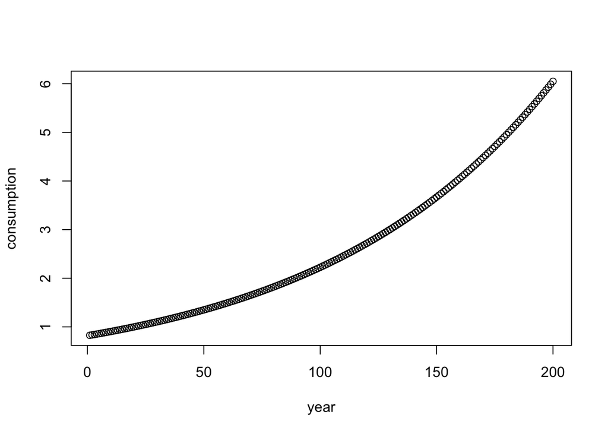

```r
# Consumption modest climate change (T = 2) (C_mcc = consumption modest climate change)
T = 2
temp = tauf(t,T)

Consumption = function(t,temp)
{
  out = Keep(temp)*exp(g*t)
  return(out)
}


DF_C_mcc = data.frame(year = seq(1,200), consumption = numeric(200))

for (t in seq(1,200))
{
  v = Consumption(t,temp)
  DF_C_mcc$consumption[t] = v
}

plot(DF_C_mcc)
```

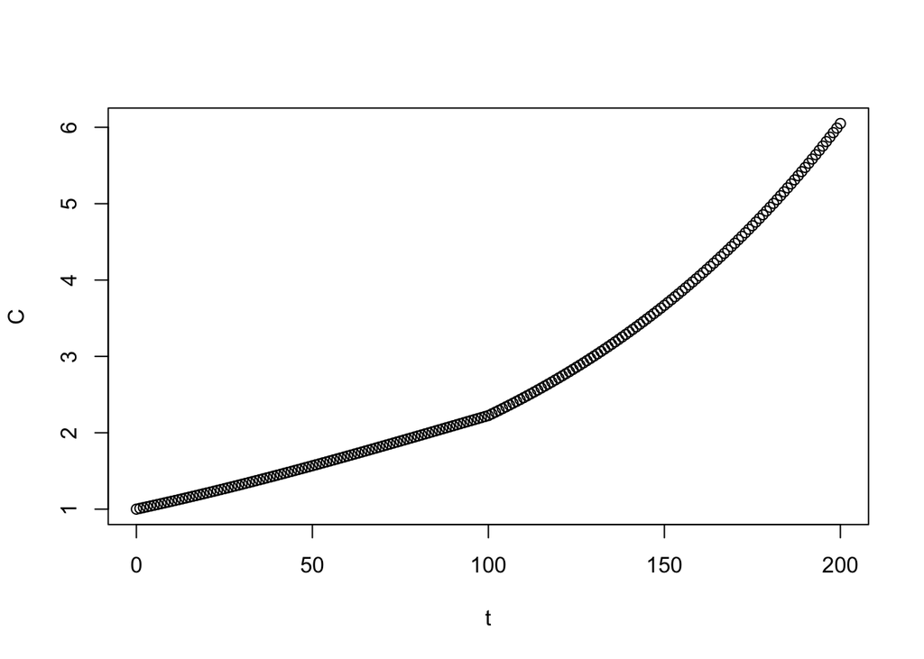

```r
# Method 2 to plot consumption with modest climate change (I think this one might be the correct one)
t = 200
T = 2
B = 0.05
g = 0.01
n = 0.50
delta = 0.005

DF_C_mcc2 = data.frame(t=seq(0,200)) %>%
  rowwise() %>%
  mutate(temperature = tauf(t,T)) %>%
  mutate(K = Keep(temperature)) %>%
  mutate(C = Consumption(t,temperature)) %>%
  mutate(U = Utility(C)) %>%
  mutate(PVU = U/(1+r)^t) %>%
  select(t,C)

plot(DF_C_mcc2)
```

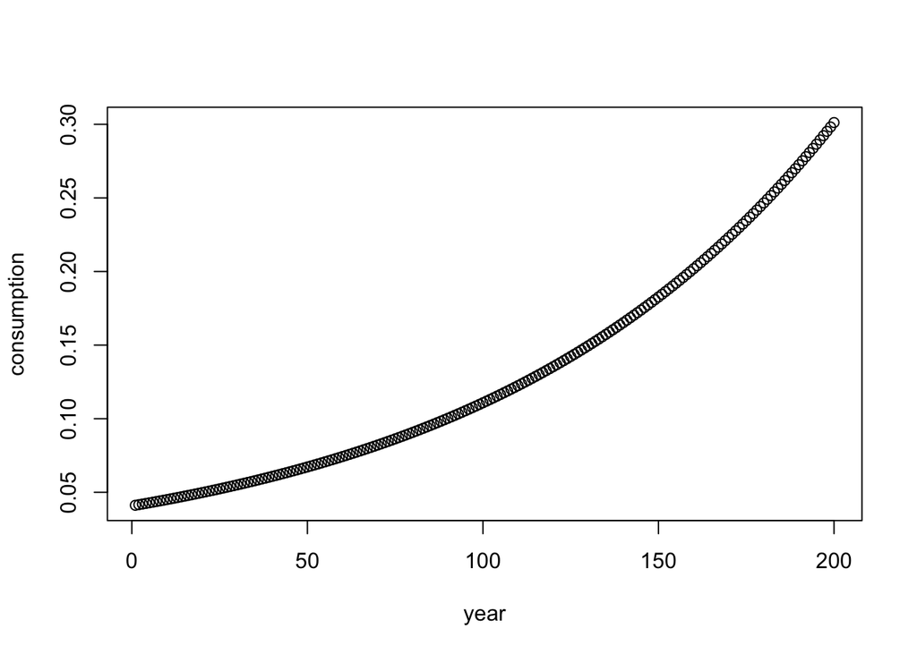

```r
# Consumption extreme climate change (T = 8) (C_ecc = consumption extreme climate change)
T = 8
temp = tauf(t,T)

Consumption = function(t,temp)
{
  out = Keep(temp)*exp(g*t)
  return(out)
}


DF_C_ecc = data.frame(year = seq(1,200), consumption = numeric(200))

for (t in seq(1,200))
{
  v = Consumption(t,temp)
  DF_C_ecc$consumption[t] = v
}

plot(DF_C_ecc)
```

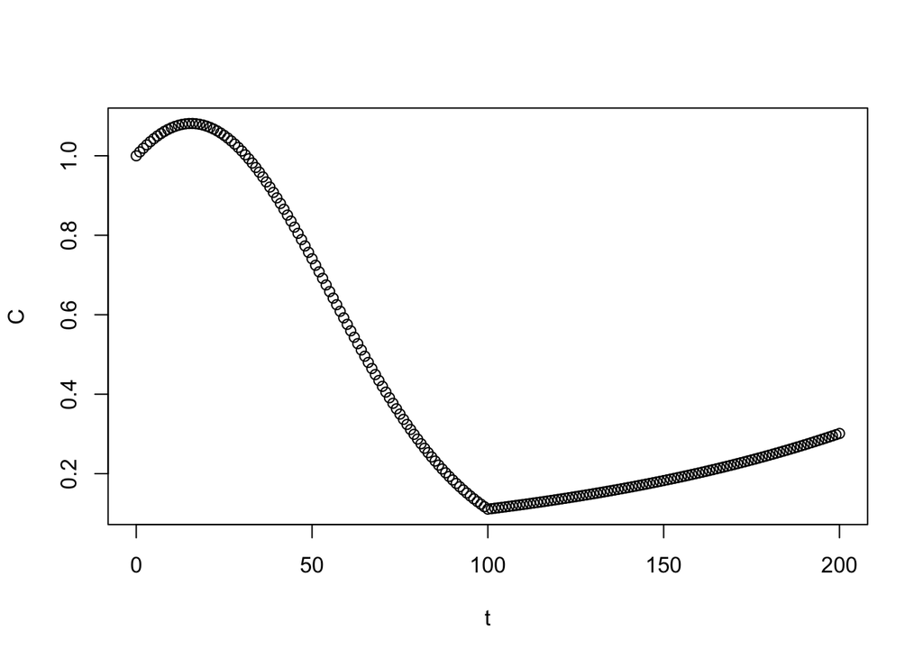

```r
# Method 2 to plot consumption with extreme climate change (I think this one might be the correct one)
t = 200
T = 8
B = 0.05
g = 0.01
n = 0.50
delta = 0.005

DF_C_ecc2 = data.frame(t=seq(0,200)) %>%
  rowwise() %>%
  mutate(temperature = tauf(t,T)) %>%
  mutate(K = Keep(temperature)) %>%
  mutate(C = Consumption(t,temperature)) %>%
  mutate(U = Utility(C)) %>%
  mutate(PVU = U/(1+r)^t) %>%
  select(t,C)


plot(DF_C_ecc2)
```

3. Plot undiscoutned utility over time for no climate change, modest climate change, and extreme climate change.

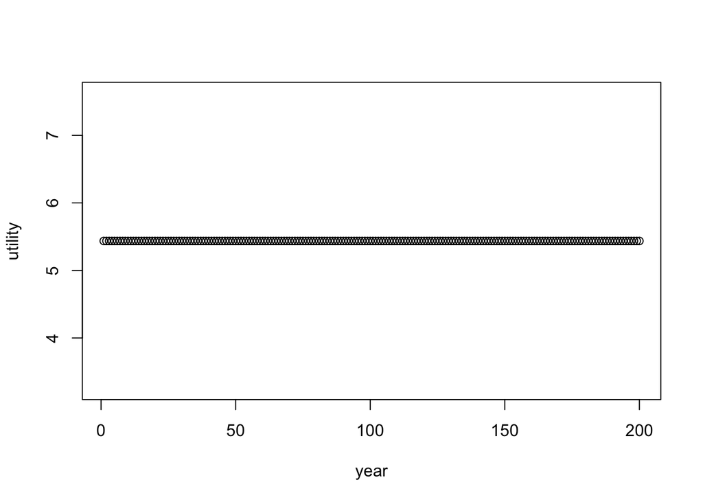

```r
# Undiscoutned utility without climate change (T = 0) #THIS IS NOT RIGHT SOMETHING IS WRONG
T = 0
temp = tauf(t,T)
C = Consumption(t,temp)

DF_U_wocc = data.frame(year = seq(1,200), utility = numeric(200))

for (t in seq(1,200))
{
  v = Utility(C)
  DF_U_wocc$utility[t] = v
}

plot(DF_U_wocc)
```

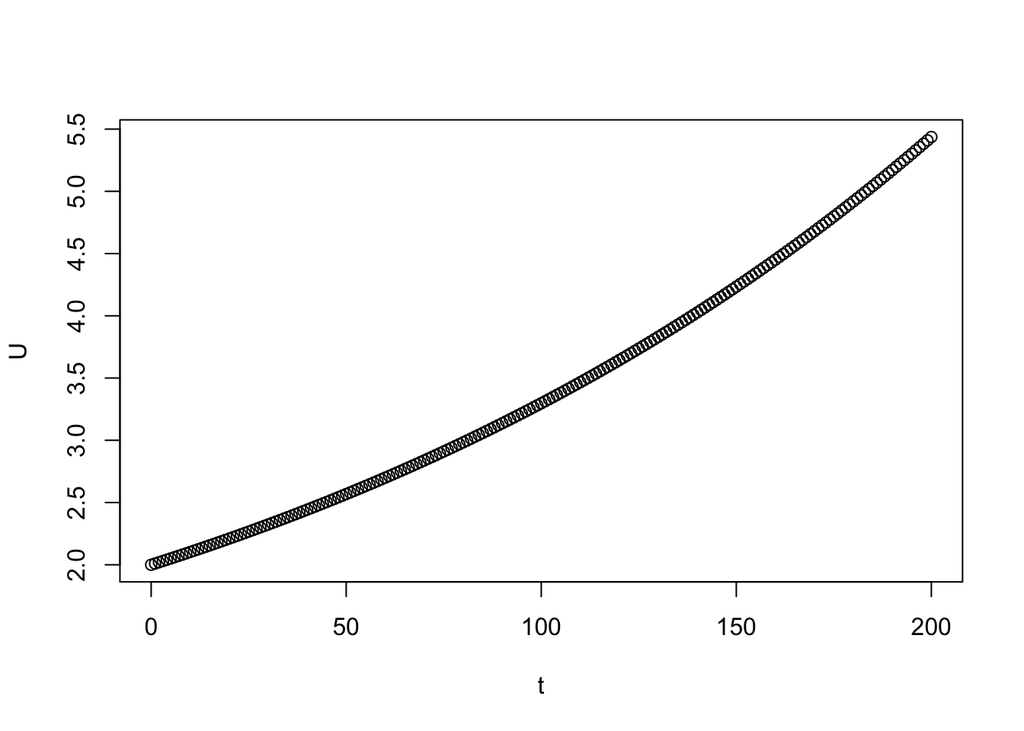

```r
# Method 2 to plot utility without climate change (I think this one is the correct one)
t = 200
T = 0
B = 0.05
g = 0.01
n = 0.50
delta = 0.005

DF_U_wocc2 = data.frame(t=seq(0,200)) %>%
  rowwise() %>%
  mutate(temperature = tauf(t,T)) %>%
  mutate(K = Keep(temperature)) %>%
  mutate(C = Consumption(t,temperature)) %>%
  mutate(U = Utility(C)) %>%
  mutate(PVU = U/(1+r)^t) %>%
  select(t,U)


plot(DF_U_wocc2)
```

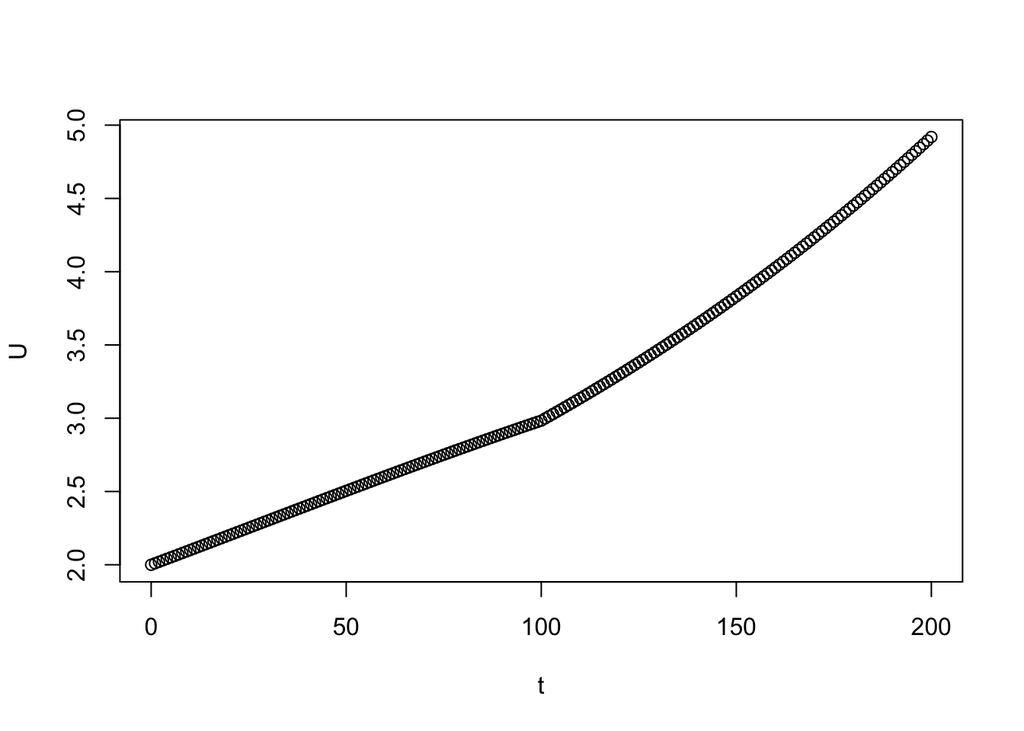

```r
# Plot utility with modest climate change (T = 2) (I think this one is the correct one)
t = 200
T = 2
B = 0.05
g = 0.01
n = 0.50
delta = 0.005

DF_U_mcc2 = data.frame(t=seq(0,200)) %>%
  rowwise() %>%
  mutate(temperature = tauf(t,T)) %>%
  mutate(K = Keep(temperature)) %>%
  mutate(C = Consumption(t,temperature)) %>%
  mutate(U = Utility(C)) %>%
  mutate(PVU = U/(1+r)^t) %>%
  select(t,U)


plot(DF_U_mcc2)
```

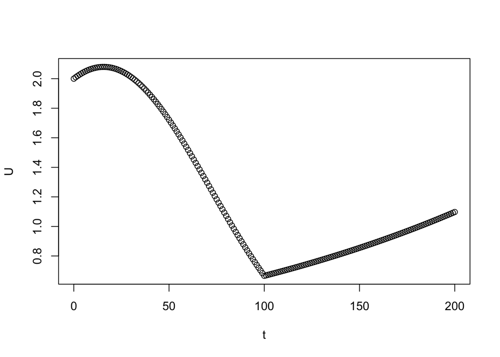

```r
# Plot utility with extreme climate change (T = 8) (I think this one is the correct one)
t = 200
T = 8
B = 0.05
g = 0.01
n = 0.50
delta = 0.005

DF_U_ecc2 = data.frame(t=seq(0,200)) %>%
  rowwise() %>%
  mutate(temperature = tauf(t,T)) %>%
  mutate(K = Keep(temperature)) %>%
  mutate(C = Consumption(t,temperature)) %>%
  mutate(U = Utility(C)) %>%
  mutate(PVU = U/(1+r)^t) %>%
  select(t,U)


plot(DF_U_ecc2)
```

QUESTION 2: ANALYSIS (a) Suppose T = 4.4. What is the present value (i.e. discounted) utility over the next 200 years with climate change? What is the present value utility without climate change? What is the percentage loss in present value utility from climate change?

```r
#This dataframe shows values for temperature, economic activity retained (K), consumption (C), utility (U), and present value utility (PVU) from years 0 to 200. It also gives the NPV which is the sum of all the PVUs over those years. Use this to compare PVU with and without climate change in question 2(a,b).

# With climate change (wcc)
t = 200
T = 4.4
B = 0.05
g = 0.01
n = 0.50
delta = 0.005

wcc_DF = data.frame(t=seq(0,200)) %>%
  rowwise() %>%
  mutate(temperature = tauf(t,T)) %>%
  mutate(K = Keep(temperature)) %>%
  mutate(C = Consumption(t,temperature)) %>%
  mutate(U = Utility(C)) %>%
  mutate(PVU = U/(1+r)^t)

  wcc_NPV = sum(wcc_DF$PVU)

# Net present value utility = 198.661219717316
```

```r
# Without climate change (wocc)
t = 200
T = 0
B = 0.05
g = 0.01
n = 0.50
delta = 0.005

wocc_DF = data.frame(t=seq(0,200)) %>%
  rowwise() %>%
  mutate(temperature = tauf(t,T)) %>%
  mutate(K = Keep(temperature)) %>%
  mutate(C = Consumption(t,temperature)) %>%
  mutate(U = Utility(C)) %>%
  mutate(PVU = U/(1+r)^t)

  wocc_NPV = sum(wocc_DF$PVU)

# Net present value utility = 255.273441757037
```

```r
# To calculate L:
# 255.273441757037 - 198.661219717316 = 56.61222
# 56.61222/255.273441757037 = 0.2217709 = 22.18%
# *L = 22.18*

L = (wocc_NPV - wcc_NPV)/wocc_NPV*100
```

````
(b)
Now, show how sensitive your calculation of L is to the following parameters: T, g, n, and B. To do so, calculate the % change in L that arises from a 10% increase in each of these parameters.

*Sensitivity to T*

```r
# With climate change sensitivity to T (10% increase of 4.4, new T = 4.84) (wcc_NPV_sT)
t = 200
T = 4.84
B = 0.05
g = 0.01
n = 0.50
delta = 0.005

wcc_DF_sT = data.frame(t=seq(0,200)) %>%
  rowwise() %>%
  mutate(temperature = tauf(t,T)) %>%
  mutate(K = Keep(temperature)) %>%
  mutate(C = Consumption(t,temperature)) %>%
  mutate(U = Utility(C)) %>%
  mutate(PVU = U/(1+r)^t)

  wcc_NPV_sT = sum(wcc_DF_sT$PVU)

# Net present value utility = 189.421099192601
```


```r
# Without climate change sensitivity to T (10% increase of 0, new T = 0) (wocc_NPV_sT)
t = 200
T = 0
B = 0.05
g = 0.01
n = 0.50
delta = 0.005

wocc_DF_sT = data.frame(t=seq(0,200)) %>%
  rowwise() %>%
  mutate(temperature = tauf(t,T)) %>%
````

[output cut: 190 more lines]

````

# Net present value utility = 255.273441757037
```

To calculate new L with 10% increase in B

```r
# To calculate L
# 255.273441757037 - 194.164520791888 = 61.10892
# 61.10892/255.273441757037 = 0.2393861 = 23.94%
# *New L = 23.94%*
# **A 10% increase in B caused L to increase from 22.18% to 23.94%**

L_B = (wocc_NPV_sB - wcc_NPV_sB)/wocc_NPV_sB*100
```
````

3. Back to the original parameters, suppose we could completely prevent climate change from ocurring (so T = 0 instead of T = 4.4) but doing so would require giving up a fraction omega of consumption every year for the next 200 years. What is the maximum value of omega society would be willing to endure every year to completely prevent climate change? Call this omegastar.